# prob3 slides

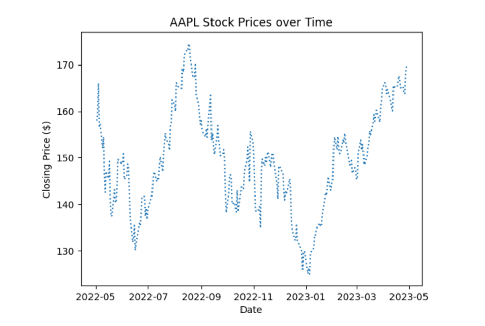

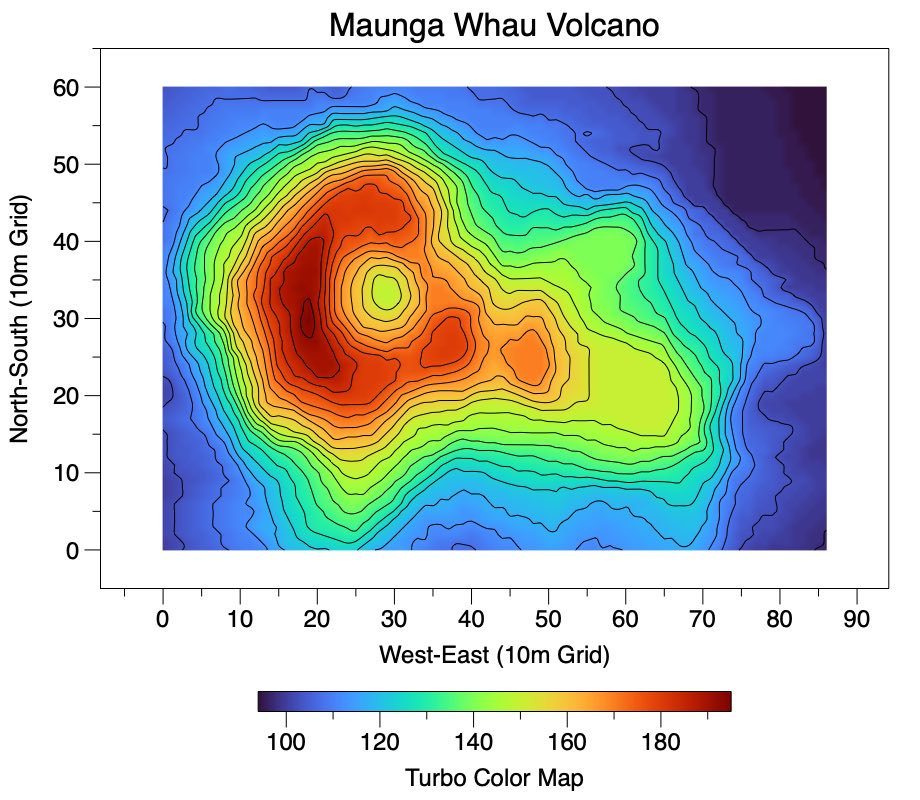

A 2D scalar field graph visualizes scalar values distributed over a two-dimensional space. The heat map of Munga Whau volcano assigns a value, such as temperature or elevation, to each location on the surface. Colors represent the magnitude of each measurement, making it easy to identify hotspots or regions of higher elevation across the volcano.

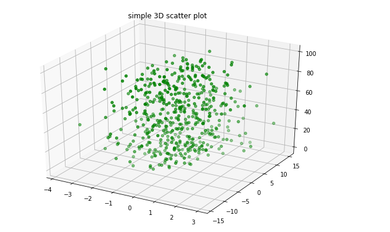

A 3D scalar field graph displays scalar or positional data in three-dimensional space. Each point in this scatter plot has x, y, and z coordinates, representing its position or value. This allows us to observe spatial patterns, clusters, and volumetric structures that cannot be fully captured in two dimensions.

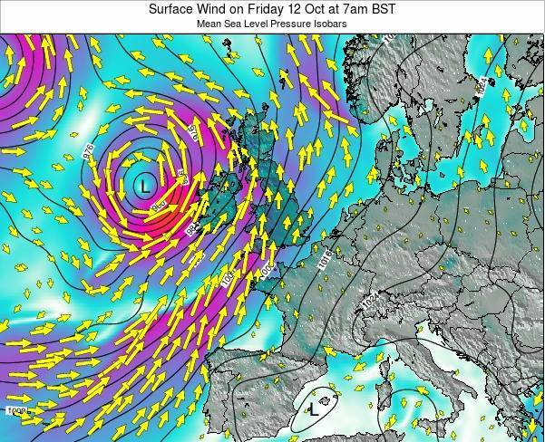

A 2D vector field graph represents data that has both magnitude and direction at each point in a two-dimensional plane. The surface wind plot shows wind speed and direction across Europe. Arrows indicate the direction of wind flow, while their size or color represents strength, revealing patterns like dominant wind currents or circulation areas.

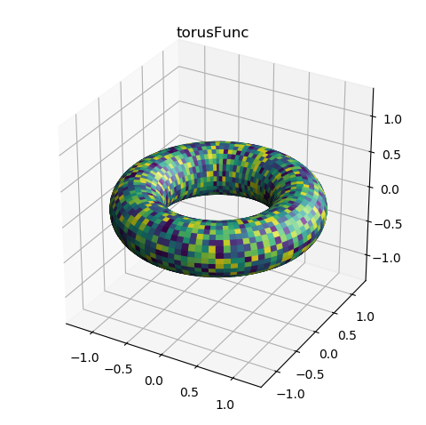

A 3D shape graph visualizes continuous geometric objects in three-dimensional space. The torus plot defines points on the surface using x, y, and z coordinates. This type of visualization shows the structure, curvature, and topology of the shape, allowing viewers to perceive its overall form from multiple angles.

[figure not shown]

A graph visualization displays relationships between entities. In this network graph, nodes represent Game of Thrones characters, and edges represent interactions or alliances. Unlike a hierarchical tree, this graph captures complex relationships, highlighting central characters, clusters, and the overall connectivity of the network.

sources

- https://www.tigerdata.com/blog/what-is-a-time-series-plot-and-how-can-you-create-one
- https://community.visualdatatools.com/datagraph/knowledge-base/command-scalar-field/
- https://www.geeksforgeeks.org/python/3d-scatter-plotting-in-python-using-matplotlib/
- https://telescoper.blog/2018/10/12/vector-calculus-weather/
- https://stackoverflow.com/questions/77212120/plot-imshow-on-a-torus-lattice-with-pbc
- https://studentwork.prattsi.org/infovis/visualization/network-graphs-of-game-of-thrones-the-tv-series/